# computational_neuroscientists

This tutorial is designed for computational neuroscientists working with network models of leaky integrate-and-fire (LIF) neurons. It will guide you through how to:

1. **Generate realistic population-level electrophysiological signals**, such as current dipole moments (CDMs) and electroencephalography (EEG) signals.
2. **Apply inverse modelling techniques** to automatically discover potential associations between network model parameters and the resulting signals.

Whether your goal is to improve the biological realism of your simulations of extracelullar signals or to extract interpretable insights from complex neural dynamics, this tutorial offers practical tools and workflows to support your research.

**Note:** To run this notebook, the [NEST simulator](https://nest-simulator.readthedocs.io/) must be installed. You can install a pre-built NEST package with:

```
conda install -c conda-forge nest-simulator=3.8
```

Similarly, to compute field potentials using the kernel method, the [`LFPykernels`](https://github.com/LFPy/LFPykernels) package must be installed via pip:

```
pip install LFPykernels
```

We will begin by running simulations using the **Hagen’s leaky integrate-and-fire (LIF) network model**, systematically varying the model’s external input, and computing CDMs using the kernel method, as well as EEGs using the New York head model. For detailed instructions on simulating this model and generating extracelullar signals, please refer to the forward modeling tutorial: *Forward modelling of neural activity*.

```python
import sys
import os
import pickle
import numpy as np
import scipy.signal as ss
import ncpi

# Define the range of external current inputs (J_ext) to be simulated.
J_ext_range = np.linspace(26, 32, 50)

def get_spike_rate(times, transient, dt, tstop):
    """
    Compute the spike rate from spike times.

    Parameters
    ----------
    times : array
        Spike times.
    transient : float
        Transient time at the start of the simulation.
    dt : float
        Simulation time step or bin size.
    tstop : float
        Simulation stop time.

    Returns
    -------
    bins : array
        Time bins.
    hist : array
        Spike rate.
    """
    bins = np.arange(transient, tstop + dt, dt)
    hist, _ = np.histogram(times, bins=bins)
    return bins, hist.astype(float)

# Append the path to parameters of the LIF network model
sys.path.append('../../examples/simulation/Hagen_model/simulation/params')

# Pre-simulated outputs from the multicompartment neuron network model
output_path = os.path.join('/DATA/multicompartment_neuron_network', 'output', 'adb947bfb931a5a8d09ad078a6d256b0')

# Path to the data files of the multicompartment neuron models
multicompartment_neuron_network_path = '/DATA/multicompartment_neuron_network'

# Simulation outputs
CDMs = []
EEGs = []

for k,J_ext in enumerate(J_ext_range):
    print(f'Simulating the LIF network model with J_ext = {J_ext} nA')

    # Load LIF_params and KernelParams
    from network_params import LIF_params
    from analysis_params import KernelParams

    # Modify the parameter
    LIF_params['J_ext'] = J_ext

    # Create the Simulation object
    sim = ncpi.Simulation(param_folder='../../examples/simulation/Hagen_model/simulation/params',
                          python_folder='../../examples/simulation/Hagen_model/simulation/python',
                          output_folder='../../examples/simulation/Hagen_model/simulation/output')

    # Save network parameters to a pickle file
    with open(os.path.join('../../examples/simulation/Hagen_model/simulation/output', 'network.pkl'), 'wb') as f:
        pickle.dump(LIF_params, f)

    # Run the simulation
    sim.simulate('simulation.py', 'simulation_params.py')

    # Load spike times
    with open(os.path.join('../../examples/simulation/Hagen_model/simulation/output', 'times.pkl'), 'rb') as f:
        times = pickle.load(f)

    # Load gids
    with open(os.path.join('../../examples/simulation/Hagen_model/simulation/output', 'gids.pkl'), 'rb') as f:
        gids = pickle.load(f)

    # Load tstop
    with open(os.path.join('../../examples/simulation/Hagen_model/simulation/output', 'tstop.pkl'), 'rb') as f:
        tstop = pickle.load(f)

    # Load dt
    with open(os.path.join('../../examples/simulation/Hagen_model/simulation/output', 'dt.pkl'), 'rb') as f:
        dt = pickle.load(f)

    # Load X and N_X
    with open(os.path.join('../../examples/simulation/Hagen_model/simulation/output', 'network.pkl'), 'rb') as f:
        LIF_params = pickle.load(f)
        P_X = LIF_params['X']
        N_X = LIF_params['N_X']

    # Transient period
    transient = KernelParams.transient
    for X in P_X:
        gids[X] = gids[X][times[X] >= transient]
        times[X] = times[X][times[X] >= transient]

    # Compute the kernel
    print('Computing the kernel...')
    potential = ncpi.FieldPotential()
    biophys = ['set_Ih_linearized_hay2011', 'make_cell_uniform']

    H_YX = potential.create_kernel(multicompartment_neuron_network_path,
                                   output_path,
                                   KernelParams,
                                   biophys,
                                   dt,
                                   tstop,
                                   electrodeParameters=None,
                                   CDM=True)

    # Compute CDM
    probe = 'KernelApproxCurrentDipoleMoment'
    CDM_data = dict(EE=[], EI=[], IE=[], II=[])

    for X in P_X:
        for Y in P_X:
            # Compute the firing rate
            bins, spike_rate = get_spike_rate(times[X], transient, dt, tstop)
            # Pick only the z-component of the CDM kernel
            kernel = H_YX[f'{X}:{Y}'][probe][2, :]
            # CDM
            sig = np.convolve(spike_rate, kernel, 'same')
            CDM_data[f'{X}{Y}'] = ss.decimate(sig,
                                              q=10,
                                              zero_phase=True)

    sum_CDM = np.array(CDM_data['EE'] + CDM_data['EI'] + CDM_data['IE'] + CDM_data['II'],dtype=np.float32)

    # Generate EEG signals from the CDM using the New York head model, with the CDM localized at the occipital lobe
    potential = ncpi.FieldPotential(kernel=False, nyhead=True, MEEG='EEG', CDM_shape=sum_CDM.shape[0])
    EEG = np.array(potential.compute_MEEG(sum_CDM, location = np.array([-24.7, -103.3, -1.46])),dtype=np.float32)

    # Collect the simulation outputs
    CDMs.append(sum_CDM)
    EEGs.append(EEG)

# Save the outputs to files
pickle.dump(CDMs, open('CDMs.pkl', 'wb'))
pickle.dump(EEGs, open('EEGs.pkl', 'wb'))

# Save J_ext range
pickle.dump(J_ext_range, open('J_ext_range.pkl', 'wb'))
```

We now compute the set of `catch22` features from EEG signals. For further details on other feature extraction methods, see the dedicated tutorial on *Feature extraction*.

```python
# -- here, I had to restart the kernel to compute the features, as the feature extraction process was freezing otherwise.
import pandas as pd
import pickle # reload module
import ncpi # reload module
import os # reload module
import numpy as np # reload module

# Load the CDMs EEGs and J_ext_range
CDMs = pickle.load(open('CDMs.pkl', 'rb'))
EEGs = pickle.load(open('EEGs.pkl', 'rb'))
J_ext_range = pickle.load(open('J_ext_range.pkl', 'rb'))

# Compute the features
df = pd.DataFrame({'Data': EEGs})
features = ncpi.Features(method='catch22')
df = features.compute_features(df)
```

Next, we’ll take a look at some CDMs, EEGs, and a few of the `catch22` features extracted from them.

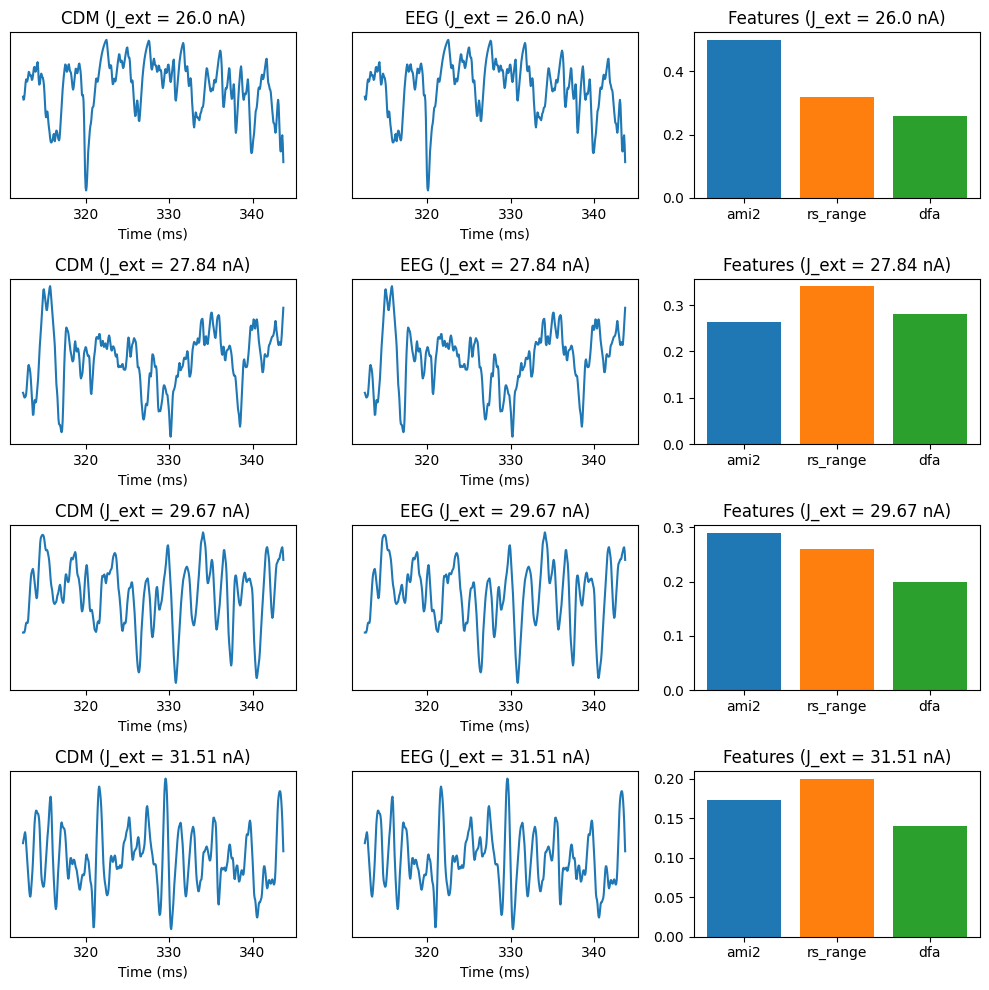

```python
import matplotlib.pyplot as plt

fig, axs = plt.subplots(4, 3, figsize=(10, 10))

# Time interval in simulation time steps
T = [5000, 5500]

# Load dt
with open(os.path.join('../../examples/simulation/Hagen_model/simulation/output', 'dt.pkl'), 'rb') as f:
    dt = pickle.load(f)

# Real time in milliseconds
time = np.arange(T[0], T[1]) * dt  # Convert from step index to time in ms

for k,J_ext in enumerate([J_ext_range[0], J_ext_range[15], J_ext_range[30], J_ext_range[45]]):

    # Find the index of J_ext in J_ext_range
    i = np.where(J_ext_range == J_ext)[0][0]

    # Plot the CDM
    axs[k, 0].plot(time, CDMs[i][T[0]:T[1]])
    axs[k, 0].set_title(f'CDM (J_ext = {np.round(J_ext,2)} nA)')
    axs[k, 0].set_xlabel('Time (ms)')
    axs[k, 0].set_yticks([])

    # Plot the EEG
    axs[k, 1].plot(time, EEGs[i][T[0]:T[1]])
    axs[k, 1].set_title(f'EEG (J_ext = {np.round(J_ext,2)} nA)')
    axs[k, 1].set_xlabel('Time (ms)')
    axs[k, 1].set_yticks([])

    # Plot the features
    axs[k, 2].bar([0], df['Features'][i][4])
    axs[k, 2].bar([1], df['Features'][i][18])
    axs[k, 2].bar([2], df['Features'][i][19])
    axs[k, 2].set_title(f'Features (J_ext = {np.round(J_ext,2)} nA)')
    axs[k, 2].set_xticks([0, 1, 2])
    axs[k, 2].set_xticklabels(['ami2', 'rs_range', 'dfa'])


plt.tight_layout()
plt.show()
```

We split the data into 90% for training and 10% for testing, as is typically done in the other tutorials.

```python
# Split simulation data into 90% training and 10% test data
indices = np.arange(len(df))
np.random.shuffle(indices)
split = int(0.9 * len(indices))
train_indices = indices[:split]
test_indices = indices[split:]

X_train = np.array(df.iloc[train_indices]['Features'].tolist())
X_test = np.array(df.iloc[test_indices]['Features'].tolist())
J_ext_train = np.array(J_ext_range)[train_indices]
J_ext_test = np.array(J_ext_range)[test_indices]
```

Here, we set up and train a model to predict the parameter `J_ext` using the features extracted earlier. For guidance on configuring other regression-based inverse models from *scikit-learn* or implementing techniques from *sbi*, see the dedicated tutorial on *Inverse modelling*.

```python
# Create the inference object and add simulation data
inference = ncpi.Inference(model='Ridge')
inference.add_simulation_data(X_train, J_ext_train)

# Train the model
inference.train(param_grid=None)
```

Let’s evaluate how well the model performs! Using the test data, we generate predictions and compare them against the true values of `J_ext`.

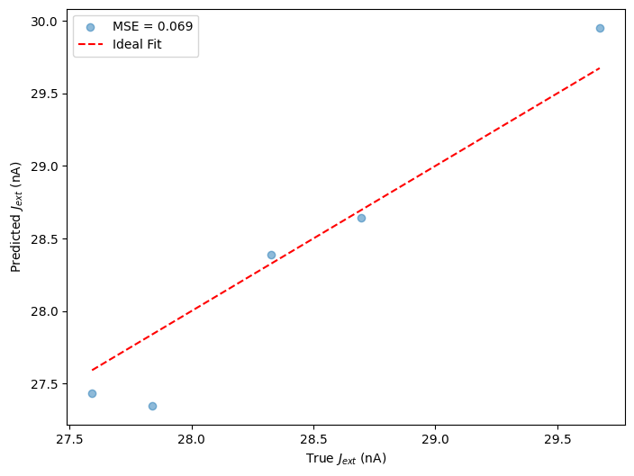

```python
from sklearn.metrics import mean_squared_error

# Evaluate the model using the test data
predictions = inference.predict(X_test)

# Calculate MSE
mse = mean_squared_error(J_ext_test, predictions)

# Plot real vs predicted values
plt.figure(figsize=(8, 6))
plt.scatter(J_ext_test, predictions, alpha=0.5, label=f'MSE = {mse:.3f}')
plt.plot([J_ext_test.min(), J_ext_test.max()], [J_ext_test.min(), J_ext_test.max()], 'r--', label='Ideal Fit')
plt.xlabel(r'$\mathrm{True\ } J_{ext}\ \mathrm{(nA)}$')
plt.ylabel(r'$\mathrm{Predicted\ } J_{ext}\ \mathrm{(nA)}$')
plt.legend()
plt.show()
```